# 07_ADacko

Aleksandra Dacko

10/26/2022

# Practical 7

```r
library(MASS)
library(splines)
library(ISLR)
library(tidyverse)
set.seed(45)
```

## Prediction plot

Median housing prices in Boston do not have a linear relation with the proportion of low SES households. Today we are going to focus exclusively on prediction.

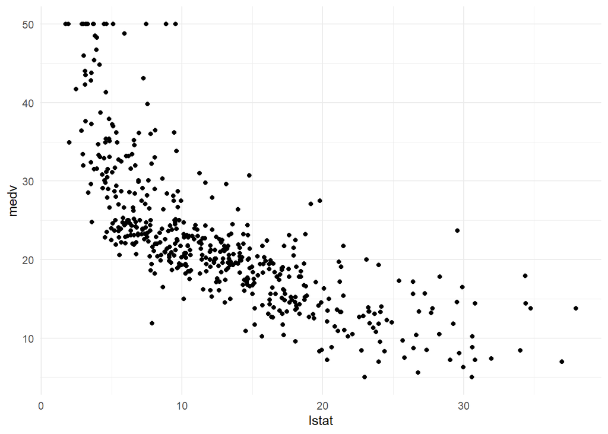

```r
Boston %>%
  ggplot(aes(x = lstat, y = medv)) +
  geom_point() +
  theme_minimal()
```

### 1.Create a function called pred_plot() that takes as input an lm object, which outputs the above plot but with a prediction line generated from the model object using the predict() method.

```r
pred_plot<-function(model){
  data<-Boston
  lstat_pred<-seq(min(data$lstat),max(data$lstat),length.out=500)
  pred_dat <-data.frame(medv=predict(model,newdata=tibble(lstat=lstat_pred)),lstat=lstat_pred)
  plot<-ggplot(aes(x = lstat, y = medv),data=Boston) +
  geom_point(colour="#979B8D")+theme_minimal()+geom_line(data=pred_dat,colour="#214E34",size=1)
  return(plot)
}
```

### 2.Create a linear regression object called lin_mod which models medv as a function of lstat. Check if your prediction plot works by running pred_plot(lin_mod). Do you see anything out of the ordinary with the predictions?

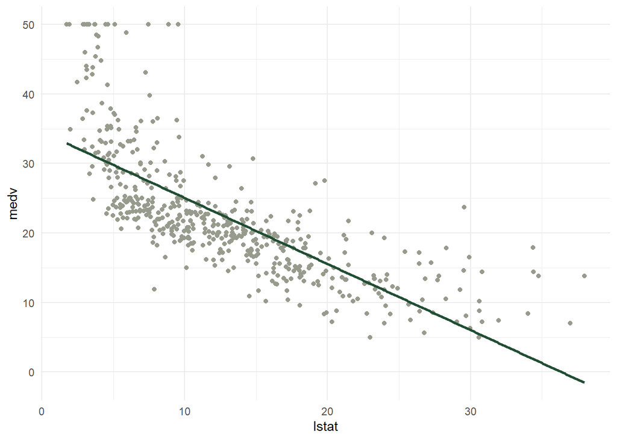

```r
lin_mod<-lm(medv~lstat,data = Boston)
pred_plot(lin_mod)
```

We can notice that the linear regression doesn’t predict the valuse on the boundaries of the data correctly.

# Polynomial regression

### 3.Create another linear model pn3_mod, where you add the second and third-degree polynomial terms I(lstat^2) and I(lstat^3) to the formula. Create a pred_plot() with this model.

```r
pn3_mod<-lm(medv~lstat+I(lstat^2)+I(lstat^3),data = Boston)
pred_plot(pn3_mod)
```

[output not shown]

This already looks more promissing.

### 4. Play around with the poly() function. What output does it generate with the arguments degree = 3 and raw = TRUE?

```r
#here we can just see values 1:5 squared and than cubed
poly(1:5, degree=3,raw = T)
```

```
##      1  2   3
## [1,] 1  1   1
## [2,] 2  4   8
## [3,] 3  9  27
## [4,] 4 16  64
## [5,] 5 25 125
## attr(,"degree")
## [1] 1 2 3
## attr(,"class")
## [1] "poly"   "matrix"
```

### 5.Use the poly() function directly in the model formula to create a 3rd-degree polynomial regression predicting medv using lstat. Compare the prediction plot to the previous prediction plot you made. What happens if you change the poly() function to raw = FALSE?

```r
lm_model_poly3_T<-lm(medv~poly(lstat, degree=3,raw = T),data=Boston)
pred_plot(lm_model_poly3_T)
```

[output not shown]

```r
lm_model_poly3_F<-lm(medv~poly(lstat, degree=3,raw = F),data=Boston)
pred_plot(lm_model_poly3_F)
```

[output not shown]

```r
head(predict(lm_model_poly3_F))
```

```
##        1        2        3        4        5        6
## 32.84026 24.21360 35.35578 38.51950 31.96809 32.26387
```

```r
head(predict(lm_model_poly3_T))
```

```
##        1        2        3        4        5        6
## 32.84026 24.21360 35.35578 38.51950 31.96809 32.26387
```

```r
summary(lm_model_poly3_F)
```

```
##
## Call:
## lm(formula = medv ~ poly(lstat, degree = 3, raw = F), data = Boston)
##
## Residuals:
##      Min       1Q   Median       3Q      Max
## -14.5441  -3.7122  -0.5145   2.4846  26.4153
##
## Coefficients:
##                                    Estimate Std. Error t value Pr(>|t|)
## (Intercept)                         22.5328     0.2399  93.937  < 2e-16 ***
## poly(lstat, degree = 3, raw = F)1 -152.4595     5.3958 -28.255  < 2e-16 ***
## poly(lstat, degree = 3, raw = F)2   64.2272     5.3958  11.903  < 2e-16 ***
## poly(lstat, degree = 3, raw = F)3  -27.0511     5.3958  -5.013 7.43e-07 ***
## ---
## Signif. codes:  0 '***' 0.001 '**' 0.01 '*' 0.05 '.' 0.1 ' ' 1
##
## Residual standard error: 5.396 on 502 degrees of freedom
## Multiple R-squared:  0.6578, Adjusted R-squared:  0.6558
## F-statistic: 321.7 on 3 and 502 DF,  p-value: < 2.2e-16
```

```r
summary(lm_model_poly3_T)
```

```
##
## Call:
## lm(formula = medv ~ poly(lstat, degree = 3, raw = T), data = Boston)
##
## Residuals:
##      Min       1Q   Median       3Q      Max
## -14.5441  -3.7122  -0.5145   2.4846  26.4153
##
## Coefficients:
##                                     Estimate Std. Error t value Pr(>|t|)
## (Intercept)                       48.6496253  1.4347240  33.909  < 2e-16 ***
## poly(lstat, degree = 3, raw = T)1 -3.8655928  0.3287861 -11.757  < 2e-16 ***
## poly(lstat, degree = 3, raw = T)2  0.1487385  0.0212987   6.983 9.18e-12 ***
## poly(lstat, degree = 3, raw = T)3 -0.0020039  0.0003997  -5.013 7.43e-07 ***
## ---
## Signif. codes:  0 '***' 0.001 '**' 0.01 '*' 0.05 '.' 0.1 ' ' 1
##
## Residual standard error: 5.396 on 502 degrees of freedom
## Multiple R-squared:  0.6578, Adjusted R-squared:  0.6558
## F-statistic: 321.7 on 3 and 502 DF,  p-value: < 2.2e-16
```

# Piecewise regression

### 6.Create a model called pw2_mod with one predictor: I(lstat <= median(lstat)). Create a pred_plot with this model. Use the coefficients in coef(pw2_mod) to find out what the predicted value for a low-lstat neighbourhood is.

```r
pw2_mod<-lm(medv~I(lstat <= median(lstat)),data=Boston)
coef(pw2_mod)
```

```
##                   (Intercept) I(lstat <= median(lstat))TRUE
##                      16.67747                      11.71067
```

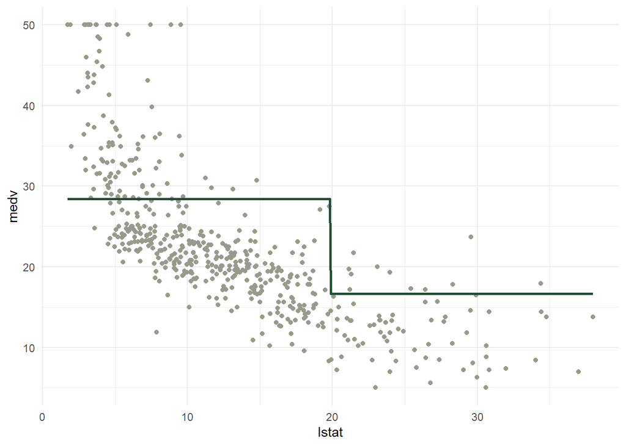

```r
pred_plot(pw2_mod)
```

From here we can see that the predicted value for high-lstat equals to the intercept value and for the low-lstat part it is equal to 16.68+11.71=28.39.

### 7. Use the cut() function in the formula to generate a piecewise regression model called pw5_mod that contains 5 equally spaced sections. Again, plot the result using pred_plot.

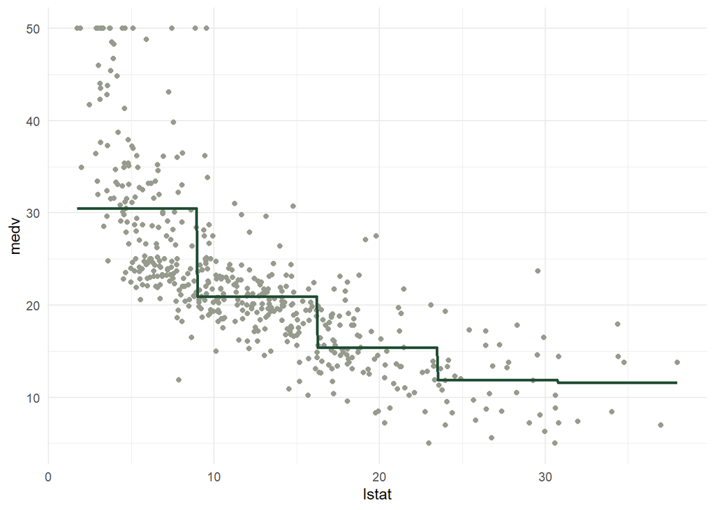

```r
pw5_mod<-lm(medv~cut(lstat,breaks = 5),data=Boston)
pred_plot(pw5_mod)
```

```r
pw5_mod$coefficients
```

```
##                       (Intercept) cut(lstat, breaks = 5)(8.98,16.2]
##                         30.505464                         -9.571038
## cut(lstat, breaks = 5)(16.2,23.5] cut(lstat, breaks = 5)(23.5,30.7]
##                        -15.143762                        -18.618978
##   cut(lstat, breaks = 5)(30.7,38]
##                        -18.916576
```

```r
#here the piece with the lowest lstat is reference category
```

```r
table(cut(Boston$lstat, 5))
```

```
##
## (1.69,8.98] (8.98,16.2] (16.2,23.5] (23.5,30.7]   (30.7,38]
##         183         183          94          37           9
```

### 8.Optional: Create a piecewise regression model pwq_mod where the sections are not equally spaced, but have equal amounts of training data. Hint: use the quantile() function.

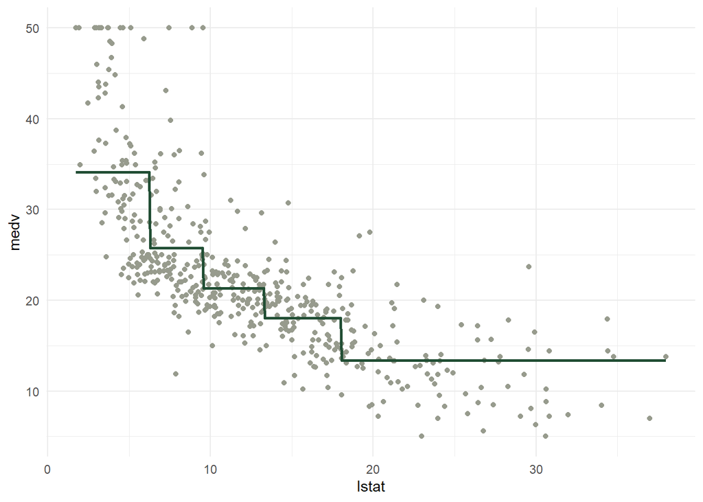

```r
breaks<-c(-Inf,quantile(Boston$lstat, probs = c(0.2,0.4,0.6,0.8)),Inf)
pwq_mod<-lm(medv~cut(lstat,breaks =breaks),data=Boston)
pred_plot(pwq_mod)
```

```r
table(cut(Boston$lstat, breaks))
```

```
##
## (-Inf,6.29] (6.29,9.53] (9.53,13.3] (13.3,18.1] (18.1, Inf]
##         102         101         101         101         101
```

# Piecewise polynomial regression

### 9. This function does not have comments. Copy - paste the function and add comments to each line. To figure out what each line does, you can first create “fake” vec and knots variables, for example vec <- 1:20 and knots <- 2 and try out the lines separately.

```r
#vec is independent variable; knots is number splits we do
piecewise_cubic_basis <- function(vec, knots = 0) {
  #we want to fit polynomial of 3rd degree to each of spitted parts of data
  if (knots == 0) return(poly(vec, degree = 3, raw = TRUE))
  #we split a vector into knots+1 equally spaced intervals
  cut_vec <- cut(vec, breaks = knots + 1)
  #we initiate a matrix of the lenght of the vector
  out <- matrix(nrow = length(vec), ncol = 0)
  #we loop throught knot+1 splits of the vector
  for (lvl in levels(cut_vec)) {
    #assign the vector to tmp
    tmp <- vec
    #if the value of the vector is not in current lvl split set it to 0
    tmp[cut_vec != lvl] <- 0
    #add polynomial of 3rd order matrix to the out matrix
    out <- cbind(out, poly(tmp, degree = 3, raw = TRUE))
  }
  #return the piecewise polynomial matrix
  out
}
```

### 10.Create piecewise cubic models with 1, 2, and 3 knots (pc1_mod - pc3_mod) using this piecewise cubic basis function. Compare them using the pred_plot() function.

```r
#just to check if it returns the 3rd degree polynomial
pc0_mod<-lm(medv~piecewise_cubic_basis(lstat),data=Boston)
pred_plot(pc0_mod) #it is indeed
```

[output not shown]

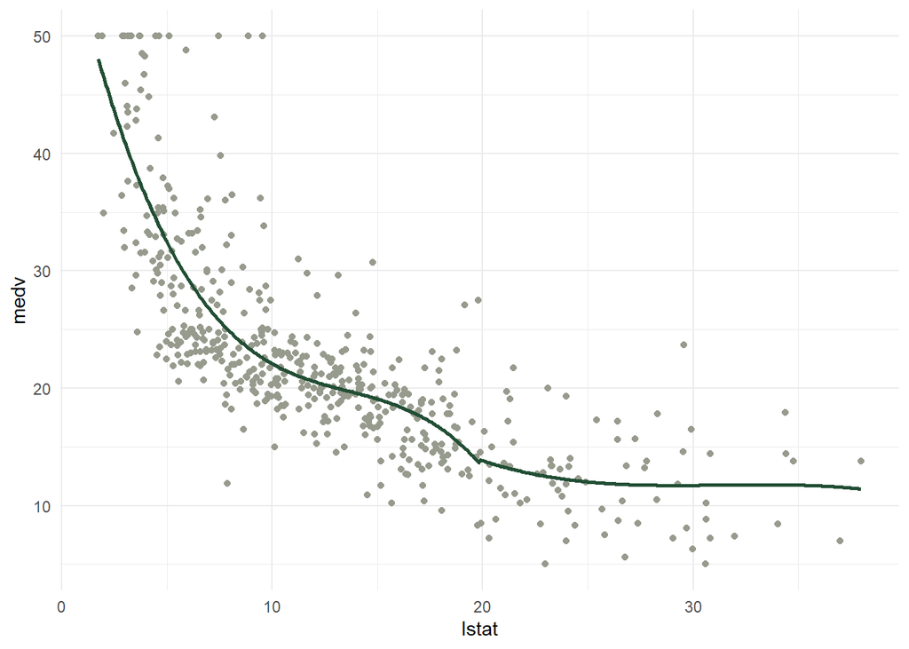

```r
pc1_mod<-lm(medv~piecewise_cubic_basis(lstat,1),data=Boston)
pred_plot(pc1_mod)#this one is already yielding a good prediction I think
```

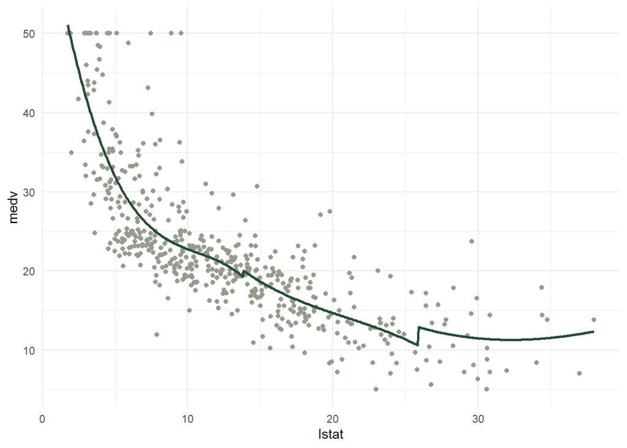

```r
pc2_mod<-lm(medv~piecewise_cubic_basis(lstat,2),data=Boston)
pred_plot(pc2_mod)
```

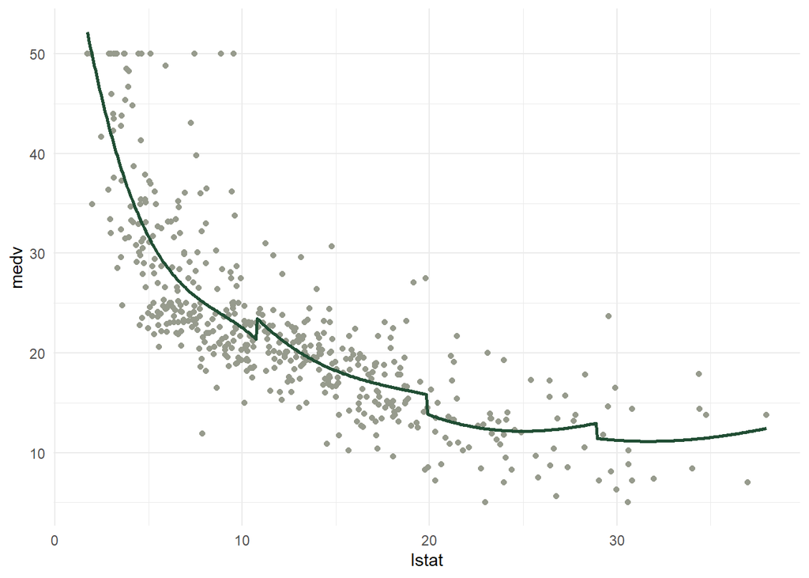

```r
pc3_mod<-lm(medv~piecewise_cubic_basis(lstat,3),data=Boston)
pred_plot(pc3_mod)
```

# Splines

### 11.Create a data frame called boston_tpb with the columns medv and lstat from the Boston dataset.

```r
boston_tpb<-data.frame(medv=Boston$medv,lstat=Boston$lstat)
```

### 12.Now use mutate to add squared and cubed versions of the lstat variable to this dataset.

```r
boston_tpb<-boston_tpb %>% mutate(lstat_v2=lstat^2,lstat_v3=lstat^3)
```

### 13.Use mutate to add a column lstat_tpb to this dataset which is 0 below the median and has value (lstat - median(lstat))^3 above the median. Tip: you may want to use ifelse() within your mutate() call.

```r
boston_tpb<-boston_tpb %>% mutate(lstat_tpb=if_else(lstat < median(lstat),0,(lstat - median(lstat))^3))
head(boston_tpb)
```

```
##   medv lstat lstat_v2  lstat_v3 lstat_tpb
## 1 24.0  4.98  24.8004 123.50599         0
## 2 21.6  9.14  83.5396 763.55194         0
## 3 34.7  4.03  16.2409  65.45083         0
## 4 33.4  2.94   8.6436  25.41218         0
## 5 36.2  5.33  28.4089 151.41944         0
## 6 28.7  5.21  27.1441 141.42076         0
```

### 14.Create a linear model tpb_mod using the lm() function. How many predictors are in the model? How many degrees of freedom does this model have?

```r
tpb_mod<-lm(medv~.,data=boston_tpb)
summary(tpb_mod)
```

```
##
## Call:
## lm(formula = medv ~ ., data = boston_tpb)
##
## Residuals:
##      Min       1Q   Median       3Q      Max
## -13.5106  -3.0547  -0.7488   2.1178  27.1383
##
## Coefficients:
##               Estimate Std. Error t value Pr(>|t|)
## (Intercept)  65.514246   3.054303  21.450  < 2e-16 ***
## lstat       -10.324275   1.089886  -9.473  < 2e-16 ***
## lstat_v2      0.856576   0.116108   7.377 6.75e-13 ***
## lstat_v3     -0.025484   0.003810  -6.688 6.05e-11 ***
## lstat_tpb     0.026582   0.004291   6.194 1.22e-09 ***
## ---
## Signif. codes:  0 '***' 0.001 '**' 0.01 '*' 0.05 '.' 0.1 ' ' 1
##
## Residual standard error: 5.206 on 501 degrees of freedom
## Multiple R-squared:  0.6822, Adjusted R-squared:  0.6796
## F-statistic: 268.8 on 4 and 501 DF,  p-value: < 2.2e-16
```

### 15. Create a cubic spline model bs1_mod with a knot at the median using the bs() function. Compare its predictions to those of the tpb_mod using the predict() function on both models.

```r
bs1_mod<-lm(medv~bs(lstat,knots=median(lstat)),data=Boston)
summary(bs1_mod)
```

```
##
## Call:
## lm(formula = medv ~ bs(lstat, knots = median(lstat)), data = Boston)
##
## Residuals:
##      Min       1Q   Median       3Q      Max
## -13.5106  -3.0547  -0.7488   2.1178  27.1383
##
## Coefficients:
##                                   Estimate Std. Error t value Pr(>|t|)
## (Intercept)                         50.085      1.549   32.34   <2e-16 ***
## bs(lstat, knots = median(lstat))1  -24.362      2.331  -10.45   <2e-16 ***
## bs(lstat, knots = median(lstat))2  -31.781      1.927  -16.49   <2e-16 ***
## bs(lstat, knots = median(lstat))3  -44.421      3.488  -12.73   <2e-16 ***
## bs(lstat, knots = median(lstat))4  -35.831      3.092  -11.59   <2e-16 ***
## ---
## Signif. codes:  0 '***' 0.001 '**' 0.01 '*' 0.05 '.' 0.1 ' ' 1
##
## Residual standard error: 5.206 on 501 degrees of freedom
## Multiple R-squared:  0.6822, Adjusted R-squared:  0.6796
## F-statistic: 268.8 on 4 and 501 DF,  p-value: < 2.2e-16
```

```r
mean(abs(predict(bs1_mod) - predict(tpb_mod)))
```

```
## [1] 3.449994e-13
```

### 16.Create a prediction plot from the bs1_mod object using the pred_plot() function.

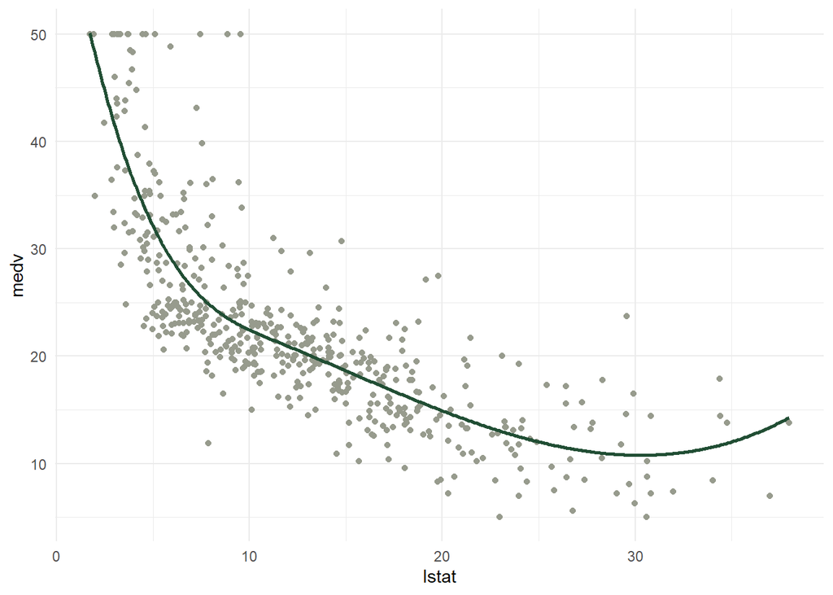

```r
pred_plot(bs1_mod)
```

### 17.Create a natural cubic spline model (ns3_mod) with 3 degrees of freedom using the ns() function. Plot it, and compare it to the bs1_mod.

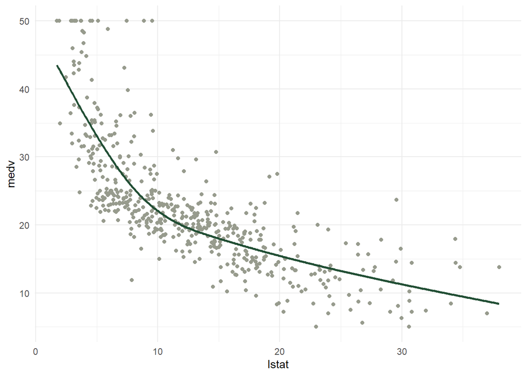

```r
ns3_mod<-lm(medv~ns(lstat,df=3),data=Boston)
pred_plot(ns3_mod)
```

```r
summary(ns3_mod)
```

```
##
## Call:
## lm(formula = medv ~ ns(lstat, df = 3), data = Boston)
##
## Residuals:
##      Min       1Q   Median       3Q      Max
## -13.7595  -3.3628  -0.6468   2.3062  27.2857
##
## Coefficients:
##                    Estimate Std. Error t value Pr(>|t|)
## (Intercept)          43.515      1.011   43.04   <2e-16 ***
## ns(lstat, df = 3)1  -20.788      1.142  -18.20   <2e-16 ***
## ns(lstat, df = 3)2  -50.868      2.455  -20.72   <2e-16 ***
## ns(lstat, df = 3)3  -24.742      1.854  -13.34   <2e-16 ***
## ---
## Signif. codes:  0 '***' 0.001 '**' 0.01 '*' 0.05 '.' 0.1 ' ' 1
##
## Residual standard error: 5.332 on 502 degrees of freedom
## Multiple R-squared:  0.6659, Adjusted R-squared:  0.6639
## F-statistic: 333.6 on 3 and 502 DF,  p-value: < 2.2e-16
```

The line represent a similarly well fit but with linear patterns at the ends. The R^2 is slightly worse for this models but the prediction line seems more sensible.

### 18.Plot lin_mod, pn3_mod, pw5_mod, pc3_mod, bs1_mod, and ns3_mod and give them nice titles by adding + ggtitle(“My title”) to the plot. You may use the function plot_grid() from the package cowplot to put your plots in a grid.

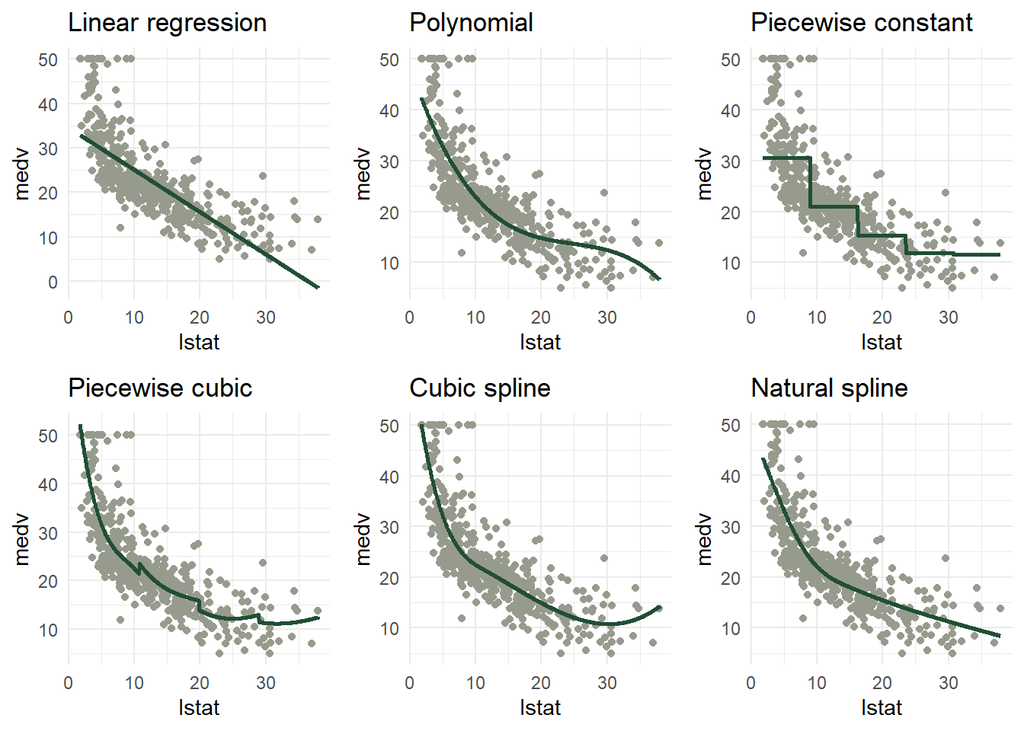

```r
library(cowplot)
plot_grid(
  pred_plot(lin_mod) + ggtitle("Linear regression"),
  pred_plot(pn3_mod) + ggtitle("Polynomial"),
  pred_plot(pw5_mod) + ggtitle("Piecewise constant"),
  pred_plot(pc3_mod) + ggtitle("Piecewise cubic"),
  pred_plot(bs1_mod) + ggtitle("Cubic spline"),
  pred_plot(ns3_mod) + ggtitle("Natural spline")
)
```

### 19. Use 12-fold cross validation to determine which of the 6 methods (lin, pn3, pw5, pc3, bs1, and ns3) has the lowest out-of-sample MSE.

```r
# first create an mse function
mse <- function(y_true, y_pred) mean((y_true - y_pred)^2)

# add a 12 split column to the boston dataset so we can cross-validate
boston_cv <- Boston %>% mutate(split = sample(rep(1:12, length.out = nrow(Boston))))

# prepare an output matrix with 12 slots per method for mse values
output_matrix <- matrix(nrow = 12, ncol = 6)
colnames(output_matrix) <- c("lin", "pn3", "pw5", "pc3", "bs1", "ns3")

# loop over the splits, run each method, and return the mse values
for (i in 1:12) {
  train <- boston_cv %>% filter(split != i)
  test  <- boston_cv %>% filter(split == i)

  brks <- c(-Inf, 7, 15, 22, Inf)

  lin_mod <- lm(medv ~ lstat,                            data = train)
  pn3_mod <- lm(medv ~ poly(lstat, 3),                   data = train)
  pw5_mod <- lm(medv ~ cut(lstat, brks),                 data = train)
  pc3_mod <- lm(medv ~ piecewise_cubic_basis(lstat, 3),  data = train)
  bs1_mod <- lm(medv ~ bs(lstat, knots = median(lstat)), data = train)
  ns3_mod <- lm(medv ~ ns(lstat, df = 3),                data = train)

  output_matrix[i, ] <- c(
    mse(test$medv, predict(lin_mod, newdata = test)),
    mse(test$medv, predict(pn3_mod, newdata = test)),
    mse(test$medv, predict(pw5_mod, newdata = test)),
    mse(test$medv, predict(pc3_mod, newdata = test)),
    mse(test$medv, predict(bs1_mod, newdata = test)),
    mse(test$medv, predict(ns3_mod, newdata = test))
  )
}
# this is the comparison of the methods
colMeans(output_matrix)
```

```
##      lin      pn3      pw5      pc3      bs1      ns3
## 38.76726 29.36707 37.95038 29.22791 27.51021 28.68858
```

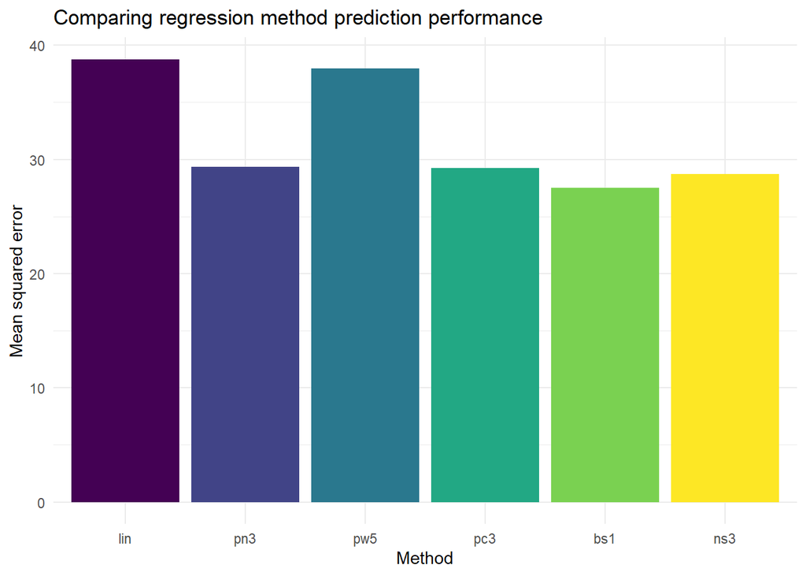

```r
##      lin      pn3      pw5      pc3      bs1      ns3
## 38.76726 29.36707 37.95038 29.22791 27.51021 28.68858
# we can show it graphically too
tibble(names = as_factor(colnames(output_matrix)),
       mse   = colMeans(output_matrix)) %>%
  ggplot(aes(x = names, y = mse, fill = names)) +
  geom_bar(stat = "identity") +
  theme_minimal() +
  scale_fill_viridis_d(guide = "none") +
  labs(
    x     = "Method",
    y     = "Mean squared error",
    title = "Comparing regression method prediction performance"
  )
```

The last two models fit the data the best !